# Tugas Analisis Regrasi Pertemuan 7

Salsa Rifda Erira_G1401221094

2024-03-05

```r
library(readxl)
library(tidyverse)
library(dplyr)
dataxy <- read_excel(path = "D:/semester 4/Analisis Regrasi/Kuliah/data minggu 7.xlsx")
dataxy <- dataxy[1:15,] %>% select(X, Y)
dataxy
```

```
## # A tibble: 15 × 2
##        X     Y
##    <dbl> <dbl>
##  1     2    54
##  2     5    50
##  3     7    45
##  4    10    37
##  5    14    35
##  6    19    25
##  7    26    20
##  8    31    16
##  9    34    18
## 10    38    13
## 11    45     8
## 12    52    11
## 13    53     8
## 14    60     4
## 15    65     6
```

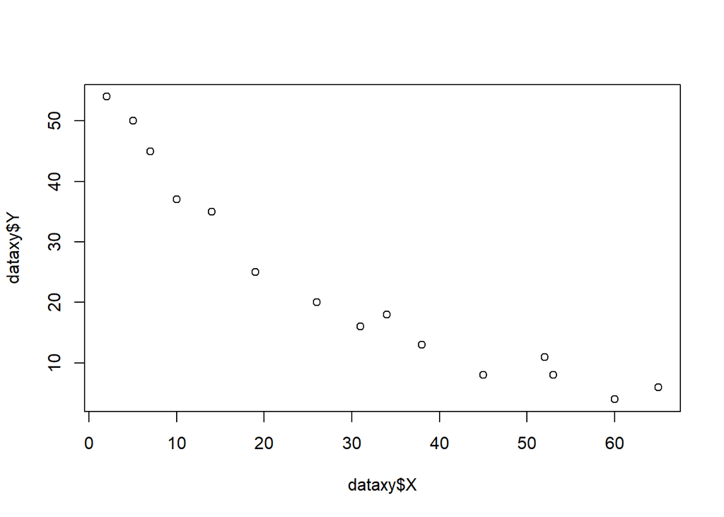

```r
library(ggplot2)
plot(x = dataxy$X, y =dataxy$Y)
```

Data menyebar secara eksponensial, tanpa ada data pencilan atau data aneh. Dengan pertimbangan belum diajarkan mencari persamaan regrasi eksponensial, maka rumus regrasi dicari melalui software excel dan didapatkan nilai

y duga = 56.665e^(-0.038x)

```r
e <- 2.718281828 # menyatakan nilai e
x <- dataxy$X
y <- dataxy$Y
alfa <- 56.665
beta <- -0.038
y_duga <- round(alfa*e^(beta*x), 3)
galat <- round(y - y_duga, 3)

tabelnilai <- data.frame(x, y, y_duga, galat)
tabelnilai
```

```
##     x  y y_duga  galat
## 1   2 54 52.518  1.482
## 2   5 50 46.860  3.140
## 3   7 45 43.430  1.570
## 4  10 37 38.751 -1.751
## 5  14 35 33.287  1.713
## 6  19 25 27.527 -2.527
## 7  26 20 21.098 -1.098
## 8  31 16 17.447 -1.447
## 9  34 18 15.567  2.433
## 10 38 13 13.372 -0.372
## 11 45  8 10.249 -2.249
## 12 52 11  7.855  3.145
## 13 53  8  7.562  0.438
## 14 60  4  5.796 -1.796
## 15 65  6  4.793  1.207
```

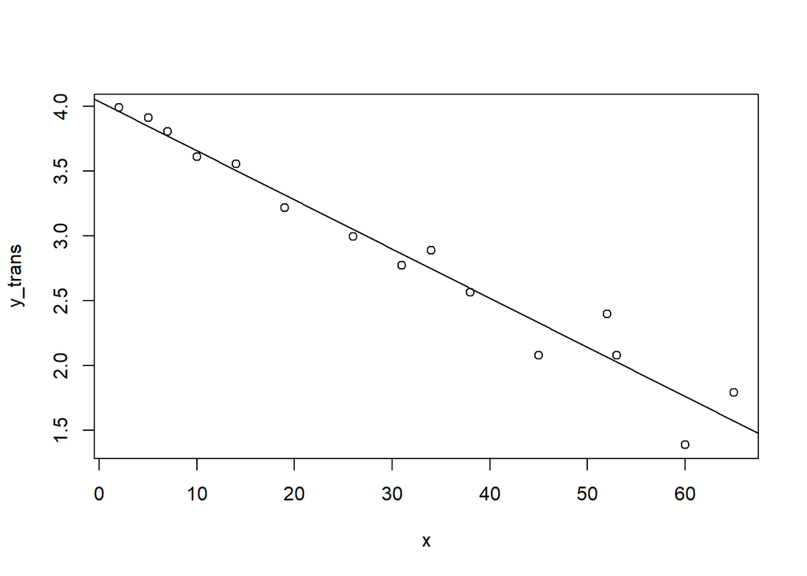

```r
# melakukan transformasi agar linear
y_trans <- log(y)

plot(x, y_trans)
abline(lm (y_trans ~ x))
```

Setelah dilakukan transformasi terlihat data bergerak linear

```r
# melakukan transformasi pada parameter
b0 <- log(alfa)
b1 <- beta
round(b0,3)
```

```
## [1] 4.037
```

```r
round(b1,3)
```

```
## [1] -0.038
```

```r
yduga_trans <- b0 + b1*x
galat_trans <- y_trans - yduga_trans

tabelnilai_trans <- data.frame(x, y_trans, yduga_trans, galat_trans)
tabelnilai_trans
```

```
##     x  y_trans yduga_trans galat_trans
## 1   2 3.988984    3.961157  0.02782731
## 2   5 3.912023    3.847157  0.06486627
## 3   7 3.806662    3.771157  0.03550575
## 4  10 3.610918    3.657157 -0.04623882
## 5  14 3.555348    3.505157  0.05019133
## 6  19 3.218876    3.315157 -0.09628091
## 7  26 2.995732    3.049157 -0.05342446
## 8  31 2.772589    2.859157 -0.08656801
## 9  34 2.890372    2.745157  0.14521502
## 10 38 2.564949    2.593157 -0.02820738
## 11 45 2.079442    2.327157 -0.24771519
## 12 52 2.397895    2.061157  0.33673854
## 13 53 2.079442    2.023157  0.05628481
## 14 60 1.386294    1.757157 -0.37086238
## 15 65 1.791759    1.567157  0.22460273
```

Jadi, diketahui persamaan regrasi linear sederhana dari eksponensial setelah ditransformasi adalah : y duga = 4.037-0.038X

```r
model <- lm(y_trans ~ x)
summary(model)
```

```
##
## Call:
## lm(formula = y_trans ~ x)
##
## Residuals:
##      Min       1Q   Median       3Q      Max
## -0.37241 -0.07073  0.02777  0.05982  0.33539
##
## Coefficients:
##              Estimate Std. Error t value Pr(>|t|)
## (Intercept)  4.037159   0.084103   48.00 5.08e-16 ***
## x           -0.037974   0.002284  -16.62 3.86e-10 ***
## ---
## Signif. codes:  0 '***' 0.001 '**' 0.01 '*' 0.05 '.' 0.1 ' ' 1
##
## Residual standard error: 0.1794 on 13 degrees of freedom
## Multiple R-squared:  0.9551, Adjusted R-squared:  0.9516
## F-statistic: 276.4 on 1 and 13 DF,  p-value: 3.858e-10
```

Dapat dilihat bahwa benar nilai intersep dan slope pada anova sama dengan nilai beta0 dan beta1 yang ditransformasi secara manual. Persamaan regresi ini cenderung merupakan model regresi terbaik jika dilihat melalui nilai R-Squared mendekati 1

Kemudian selanjutnya kita akan melakukan uji asumsi.

## Uji Asumsi

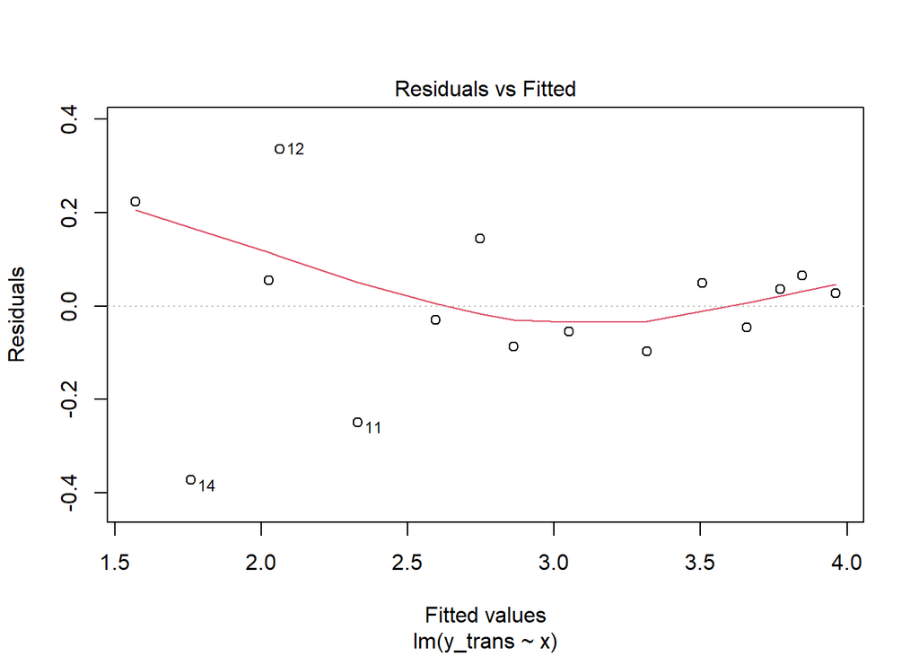

```r
# plot persebaran nilai ragam
plot(model, 1)
```

Melalui scatterplot, terlihat data masih berada di sekitar 0 tetapi memiliki lebar keragaman yang berbeda (ragam cenderung berbentuk corong). Ragam kemungkinan bersifat Heterodixcity

Uji Breusch-Pagan dilakukan sebagai pembuktian H0 : Ragam Homogen H1 : Ragam tidak homogen

```r
library(lmtest)
homogen <- bptest(model)
homogen
```

```
##
##  studentized Breusch-Pagan test
##
## data:  model
## BP = 6.9535, df = 1, p-value = 0.008365
```

Nilai P-value pada uji kehomogonan itu menyatakan ada perbedaan yang cukup signifikan dalam galat. Galat tidak homogen, cenderung berbentuk corong. Dibutuhkan analisis kuadrat tekecil terboboti.

Selanjutnya disajikan cara untuk menccari tahu apakah galat saling bebas

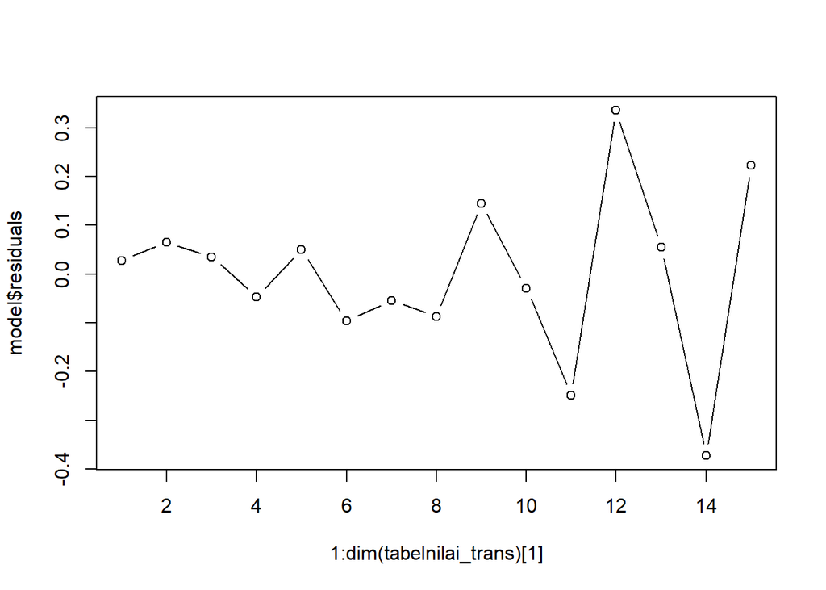

```r
# uji galat acak
plot(x = 1:dim(tabelnilai_trans)[1],
     y = model$residuals,
     type = 'b')
```

Ragam cenderung berpola, tapi akan dilakukan uji runs.test H0 : Galat acak saling bebas H1 : Galat tak acak dan tak saling bebas

```r
library(randtests)
runs.test(model$residuals)
```

```
##
##  Runs Test
##
## data:  model$residuals
## statistic = 0.55635, runs = 9, n1 = 7, n2 = 7, n = 14, p-value = 0.578
## alternative hypothesis: nonrandomness
```

Nilai p-value lebih besar dari 0.05 H0 diterima, galat acak saling bebas

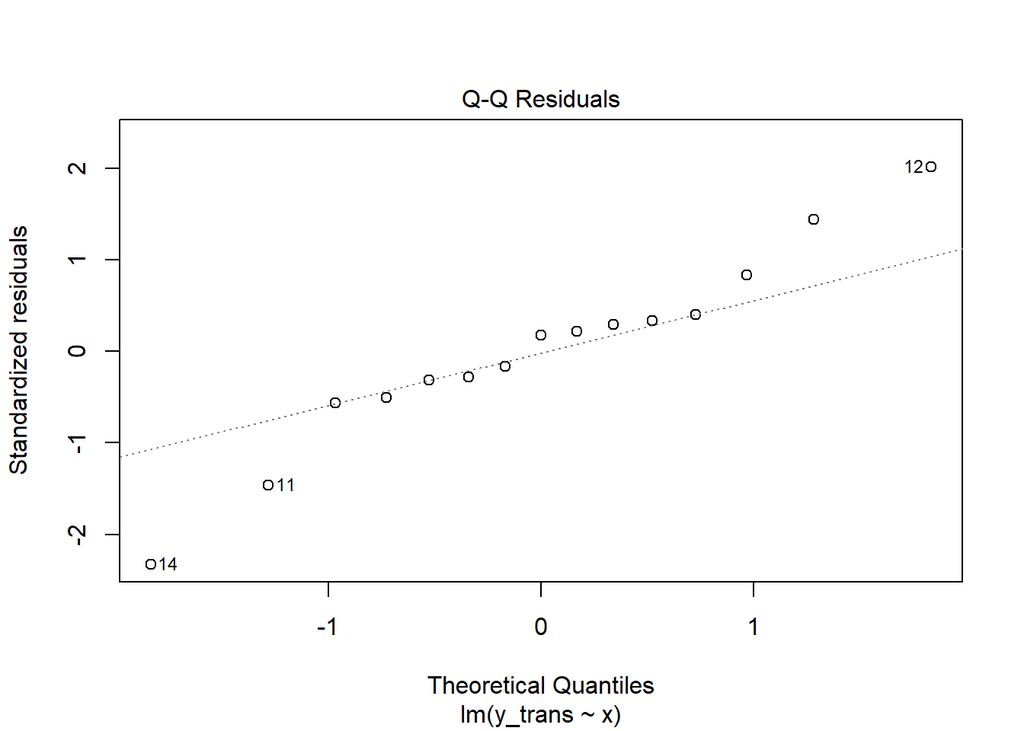

```r
# Uji kenormalan Galat
plot(model, 2)
```

Melalui Plot QQ galat, sebaran cenderung simetris dengan ujung-ujung menipis. Sebagai pembuktian akan dilakukan shapiro-wilk test

H0 = data menyebar normal H1 = Data tidak menyebar normal

```r
shapiro.test(model$residuals)
```

```
##
##  Shapiro-Wilk normality test
##
## data:  model$residuals
## W = 0.96487, p-value = 0.7762
```

p-value lebih besar dari 0.05.Hal ini berarti hipotesis terima H0 yaitu data menyebar normal

Diantara 3 asumsi Gauss-Markov, 1 asumsi tidak terpenuhi yaitu asumsi galat menyebar homogen. Untuk melanjutkan ke tahapan selanjutnya, maka perlu dilakukan analisis kuadrat terkecil terboboti.

```r
# weight least squares

# nyatakan bobot untuk digunakan
bobot <- 1/((model$fitted.values)^2)

# model analisis regresi bobot terkecil

wls_model <- lm(y_trans ~ x, data = tabelnilai_trans, weights = bobot)
summary(wls_model)
```

```
##
## Call:
## lm(formula = y_trans ~ x, data = tabelnilai_trans, weights = bobot)
##
## Weighted Residuals:
##      Min       1Q   Median       3Q      Max
## -0.22264 -0.02085  0.01294  0.02128  0.15618
##
## Coefficients:
##              Estimate Std. Error t value Pr(>|t|)
## (Intercept)  4.012204   0.143682   27.92 5.44e-13 ***
## x           -0.037239   0.003058  -12.18 1.75e-08 ***
## ---
## Signif. codes:  0 '***' 0.001 '**' 0.01 '*' 0.05 '.' 0.1 ' ' 1
##
## Residual standard error: 0.09149 on 13 degrees of freedom
## Multiple R-squared:  0.9194, Adjusted R-squared:  0.9132
## F-statistic: 148.3 on 1 and 13 DF,  p-value: 1.751e-08
```

```r
homogen2 <- bptest(wls_model)
homogen2
```

```
##
##  studentized Breusch-Pagan test
##
## data:  wls_model
## BP = 2.3997, df = 1, p-value = 0.1214
```

Setelah dilakukan pembobotan, galat bernilai homogen. Hal ini dapat dilihat melalui standar error sisaan yang berkurang dari 0.1794 menjadi 0.09149. Akan tetapi nilai R-Squared juga berkurang dari 0.9551 menjadi 0.9194 yang menandakan bahwa regresi terbobot ini tak lebih mewakilkan nilai y terhadap x dibandingkan regresi awal sebelum dilakukan pembobotan.

Persamaan regrasi y duga = 4.012 - 0.037X

```r
yduga <- 4.012 - 0.037*x
tabelnilairegresi <- data.frame(y_trans, yduga)
tabelnilairegresi
```

```
##     y_trans yduga
## 1  3.988984 3.938
## 2  3.912023 3.827
## 3  3.806662 3.753
## 4  3.610918 3.642
## 5  3.555348 3.494
## 6  3.218876 3.309
## 7  2.995732 3.050
## 8  2.772589 2.865
## 9  2.890372 2.754
## 10 2.564949 2.606
## 11 2.079442 2.347
## 12 2.397895 2.088
## 13 2.079442 2.051
## 14 1.386294 1.792
## 15 1.791759 1.607
```